# H24061024_hw10

```r
1+1
```

```
## [1] 2
```

```r
3-5
```

```
## [1] -2
```

```r
4*6
```

```
## [1] 24
```

```r
12/4
```

```
## [1] 3
```

```r
3^4
```

```
## [1] 81
```

```r
31%%7
```

```
## [1] 3
```

```r
31%/%7
```

```
## [1] 4
```

# Elements storage

## vector

### use *c()* function to collect a list of numbers into a vector

```r
x<-c(5,7,8)
x
```

```
## [1] 5 7 8
```

### vectors can be joined together

```r
y<-c(x,6:1)
y
```

```
## [1] 5 7 8 6 5 4 3 2 1
```

### extract elements from vectors

```r
y[5]
```

```
## [1] 5
```

```r
y[c(1,3,5)]
```

```
## [1] 5 8 5
```

```r
y[-2]
```

```
## [1] 5 8 6 5 4 3 2 1
```

```r
y[-(3:5)]
```

```
## [1] 5 7 4 3 2 1
```

### vector arithmetic

```r
z<-x-4
z
```

```
## [1] 1 3 4
```

```r
z*2
```

```
## [1] 2 6 8
```

```r
z^2
```

```
## [1]  1  9 16
```

```r
x^z
```

```
## [1]    5  343 4096
```

```r
y%%2:4
```

```
## [1] 1 1 0 0 2 0 1 2 1
```

### simple patterned vectors

```r
seq(1,9,by=2)
```

```
## [1] 1 3 5 7 9
```

```r
rep(3,5)
```

```
## [1] 3 3 3 3 3
```

```r
rep(seq(2,6,2),2)
```

```
## [1] 2 4 6 2 4 6
```

```r
rep(c(1,4),c(3,2))
```

```
## [1] 1 1 1 4 4
```

```r
rep(c(1,2,4),each=3)
```

```
## [1] 1 1 1 2 2 2 4 4 4
```

### missing values and other special values

the missing value symbol is *NA*

```r
evens<-NULL
evens[seq(2,10,2)]<-seq(2,10,2)
evens
```

```
##  [1] NA  2 NA  4 NA  6 NA  8 NA 10
```

a value which is “not a number” is *NAN*,usually 0/0

```r
x<-c(0,7,8)
x/x
```

```
## [1] NaN   1   1
```

*Inf*,usually 1/0

```r
1/x
```

```
## [1]       Inf 0.1428571 0.1250000
```

*numeric(0)* is a numeric vector of length 0

```r
x[0.4]
```

```
## numeric(0)
```

```r
x[1.8]
```

```
## [1] 0
```

### character vector

```r
x<-c("red","yellow","blue")
y<-c(x,"green")
y
```

```
## [1] "red"    "yellow" "blue"   "green"
```

an attempt to mix data types in a vector will lead to a result that numbers will be converted to the character type

```r
z<-c(y,1)
z
```

```
## [1] "red"    "yellow" "blue"   "green"  "1"
```

to take substrings,use *substr(x,start,stop)*

```r
substr(z,2,4)
```

```
## [1] "ed"  "ell" "lue" "ree" ""
```

to concatenate characters

```r
paste(x," flower","s",sep="")
```

```
## [1] "red flowers"    "yellow flowers" "blue flowers"
```

*collapse* parameter allows all the components of the resulting vector to be collapsed into a single string

```r
paste(x," flowers",collapse=", ")
```

```
## [1] "red  flowers, yellow  flowers, blue  flowers"
```

### factors and levels

```r
x<-c("control","treatment","control","test","treatment")
y<-factor(x)
y
```

```
## [1] control   treatment control   test      treatment
## Levels: control test treatment
```

to see the levels

```r
levels(y)
```

```
## [1] "control"   "test"      "treatment"
```

to see how the levels coded

```r
as.integer(y)
```

```
## [1] 1 3 1 2 3
```

the original data can be rewrite as

```r
levels(y)[as.integer(y)]
```

```
## [1] "control"   "treatment" "control"   "test"      "treatment"
```

### other

to detect where are missing values

```r
is.na(evens)
```

```
##  [1]  TRUE FALSE  TRUE FALSE  TRUE FALSE  TRUE FALSE  TRUE FALSE
```

## matrix

```r
m<-matrix(1:6,nrow=2,ncol=3)
m
```

```
##      [,1] [,2] [,3]
## [1,]    1    3    5
## [2,]    2    4    6
```

```r
m[1,2]
```

```
## [1] 3
```

```r
m[5]
```

```
## [1] 5
```

```r
m[1,]
```

```
## [1] 1 3 5
```

```r
m[,1]
```

```
## [1] 1 2
```

## array

```r
a<-array(1:24,c(3,4,2))
```

## data frame

```r
colors<-c("red","yellow","blue","green")
numbers<-c(1,2,3,4)
c.a.n<-data.frame(colors,numbers,more.n=5:8)
c.a.n
```

```
##   colors numbers more.n
## 1    red       1      5
## 2 yellow       2      6
## 3   blue       3      7
## 4  green       4      8
```

# Plot statistical graphics

## high-level

### barchart

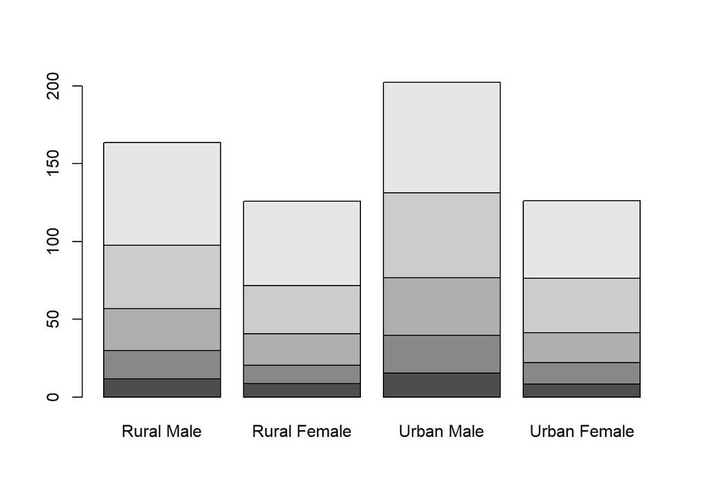

```r
barplot(VADeaths)
```

### dotchart

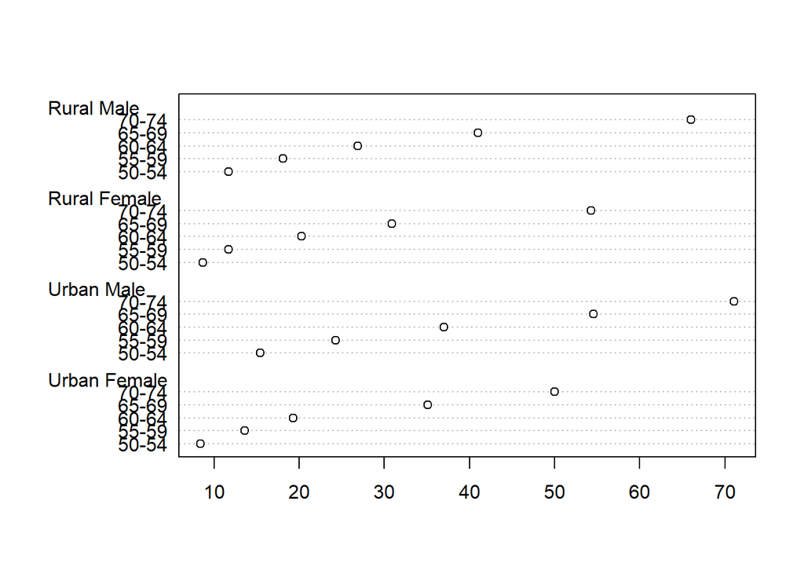

```r
dotchart(VADeaths)
```

### piechart

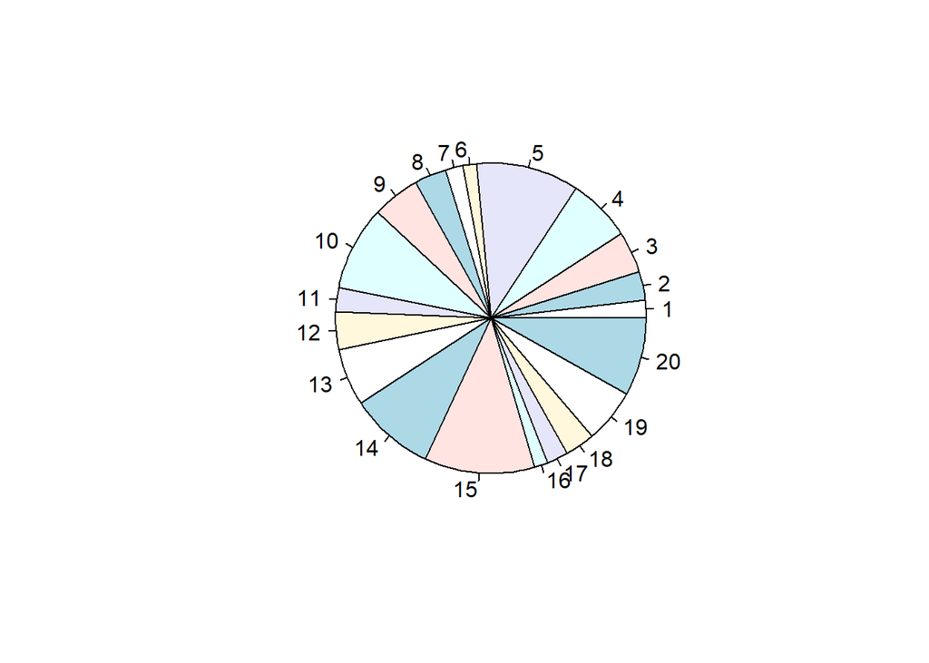

```r
pie(VADeaths)
```

### histogram

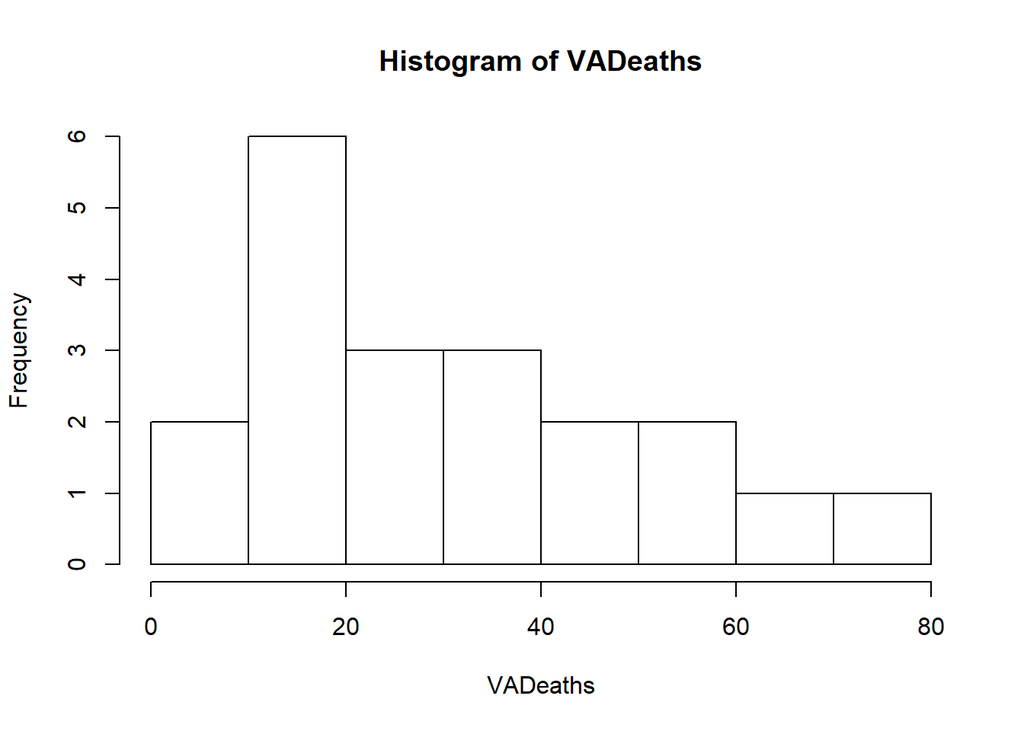

```r
hist(VADeaths)
```

### box plot

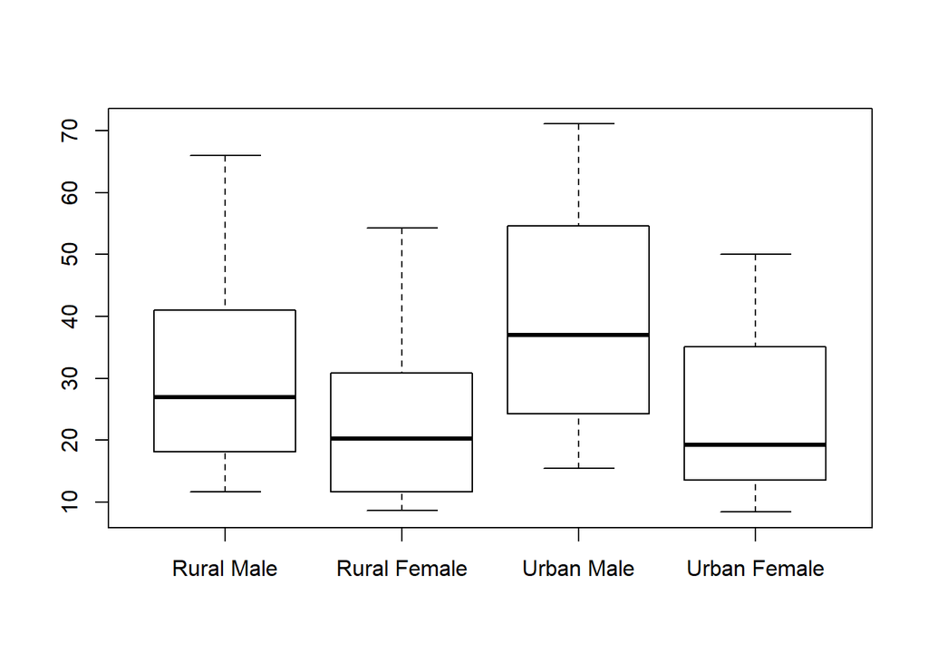

```r
boxplot(VADeaths)
```

### scatterplot

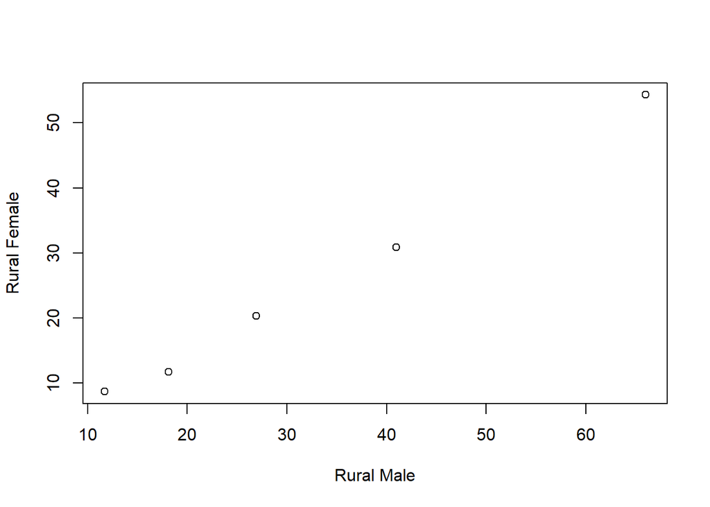

```r
plot(VADeaths)
```

### Normal

*rnorm(n,mean,sd)*

```r
rnorm(10, -3, 0.5)
```

```
##  [1] -1.842362 -3.107673 -2.832694 -3.493106 -2.312418 -3.332961 -3.479384
##  [8] -2.310787 -3.604939 -2.090189
```

### QQplot

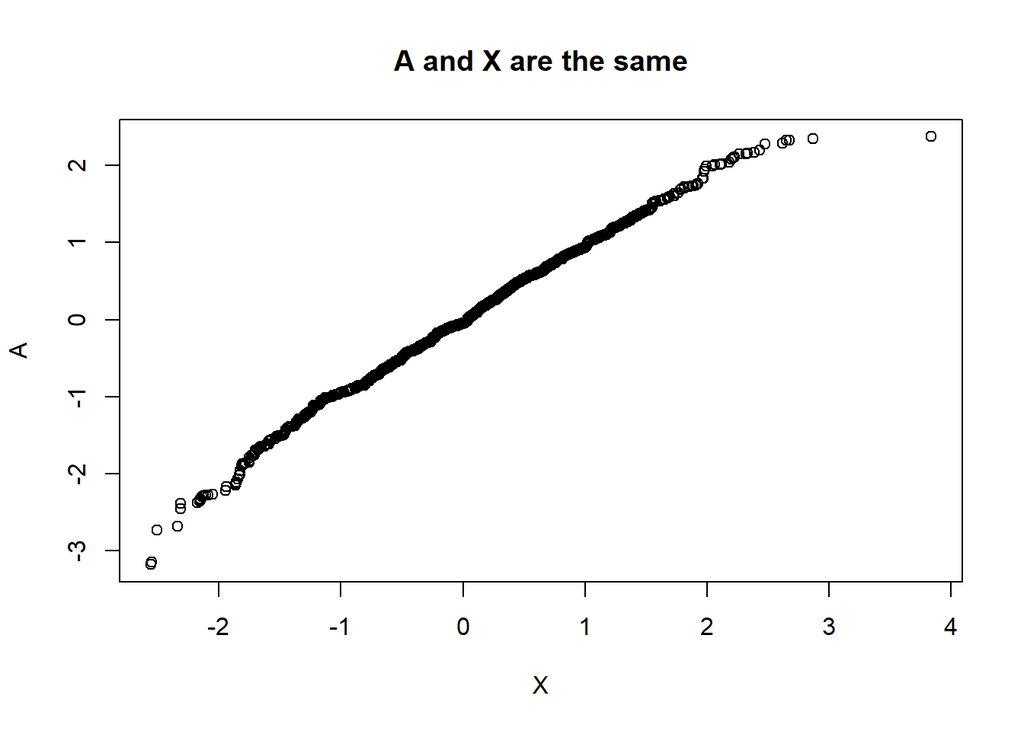

```r
#qqplot(VADeaths)
X <- rnorm(1000)
A <- rnorm(1000)
qqplot(X, A, main="A and X are the same")
```

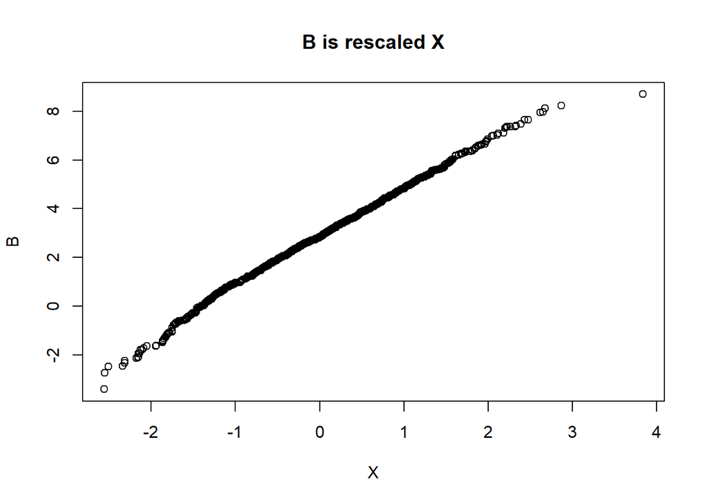

```r
B <- rnorm(1000, mean=3, sd=2)
qqplot(X, B, main="B is rescaled X")
```

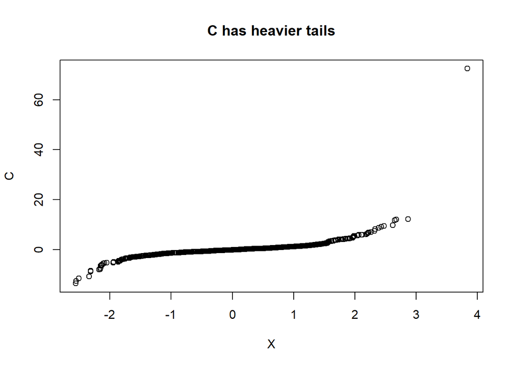

```r
C <- rt(1000, df=2)
qqplot(X, C, main="C has heavier tails")
```

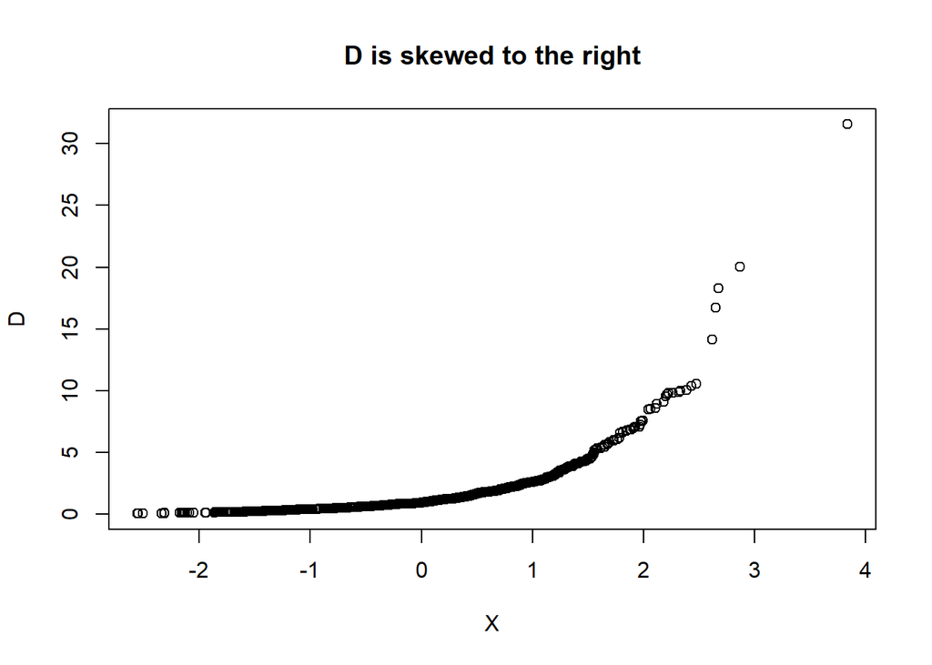

```r
D <- exp(rnorm(1000))
qqplot(X, D, main="D is skewed to the right")
```

## low-level

### add points

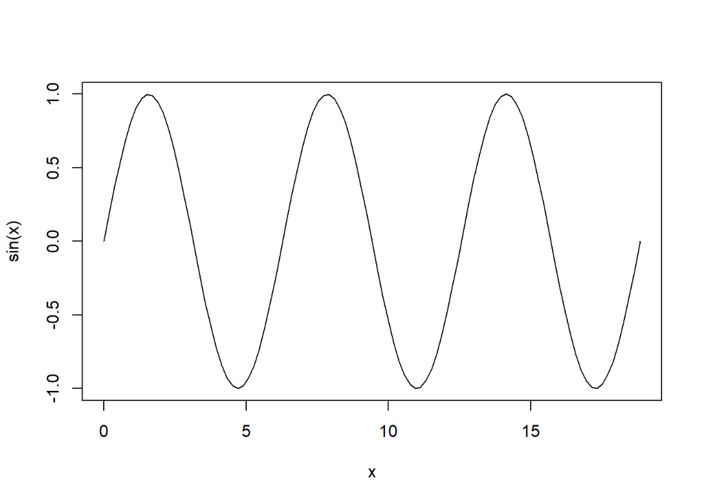

```r
curve(expr=sin,from=0,to=6*pi)
```

### barchart

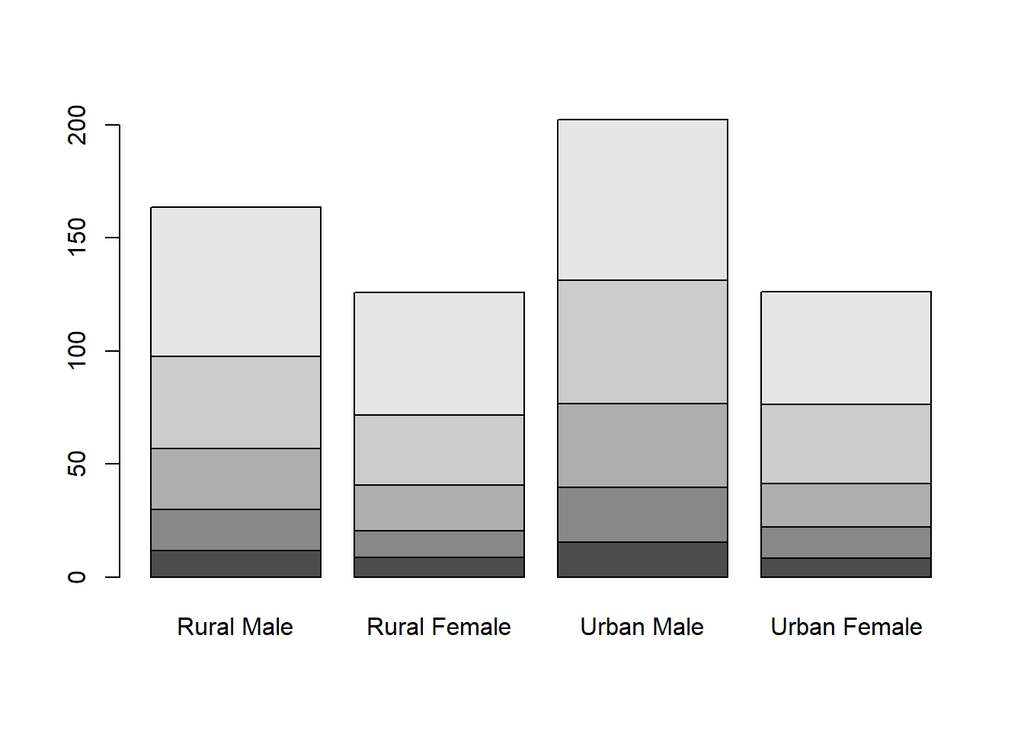

```r
barplot(VADeaths)
```

### dotchart

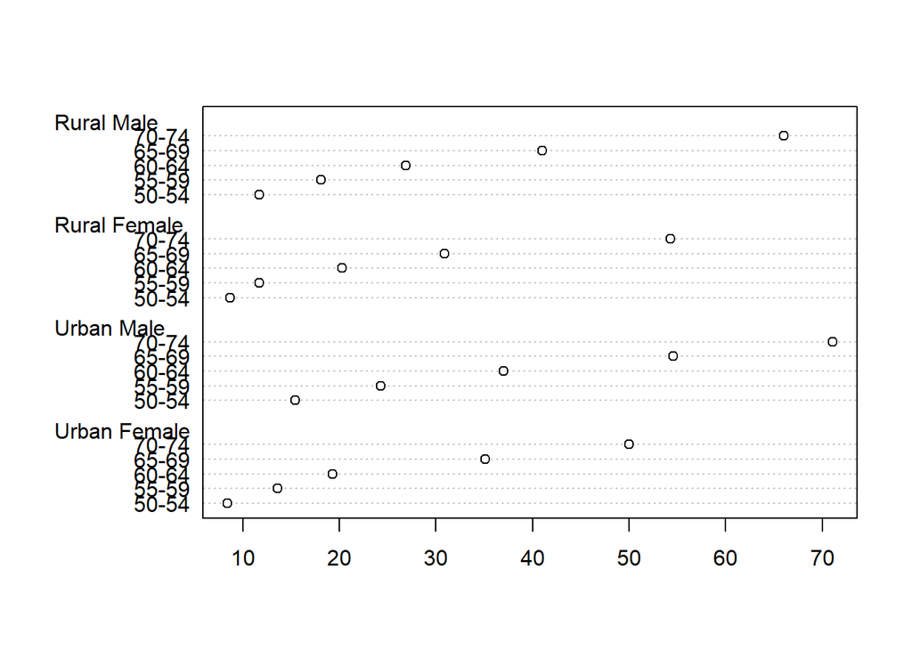

```r
dotchart(VADeaths)
```

### piechart

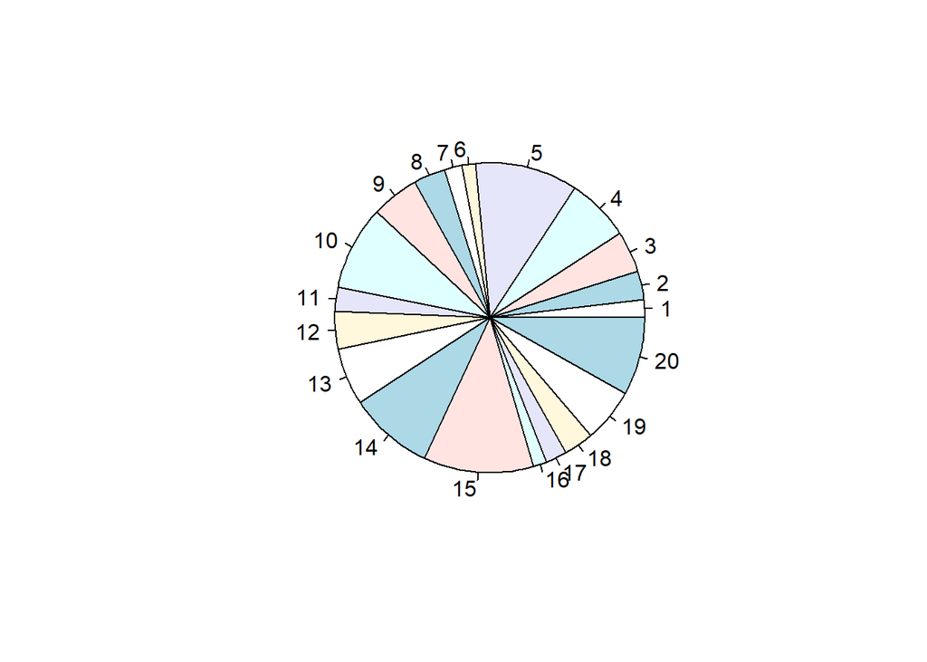

```r
pie(VADeaths)
```

### histogram

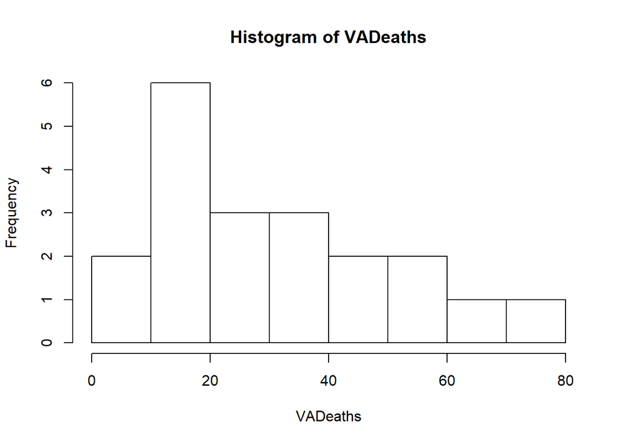

```r
hist(VADeaths)
```

### box plot

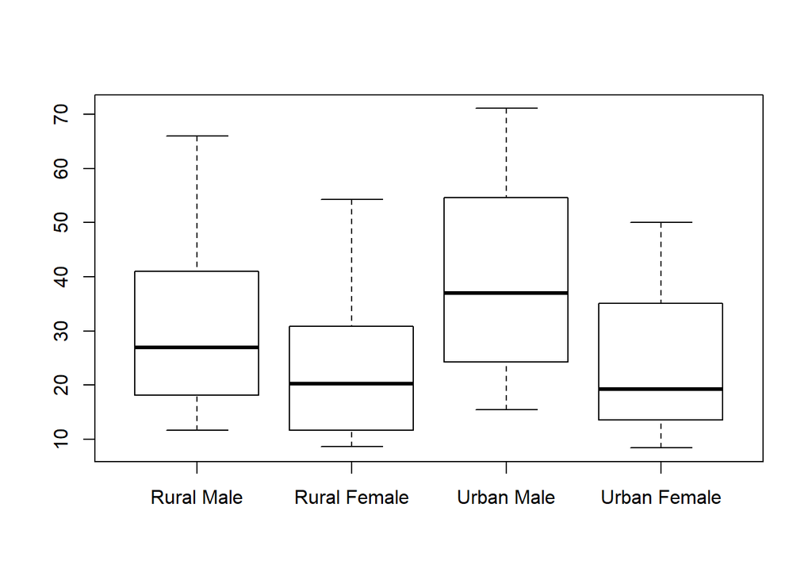

```r
boxplot(VADeaths)
```

### scatterplot

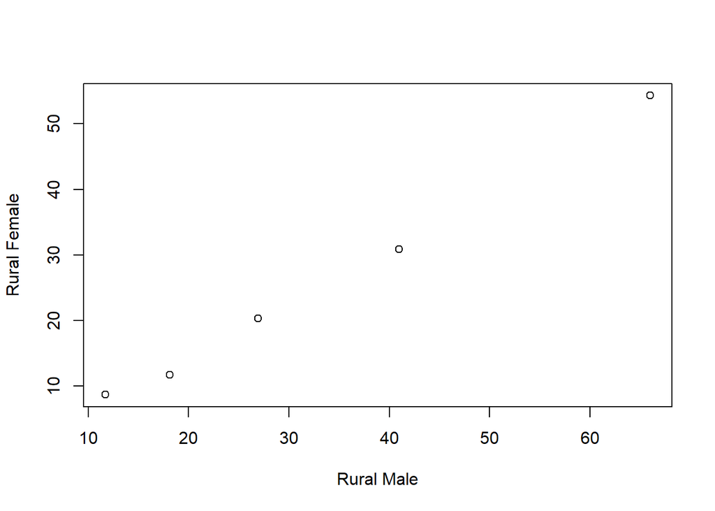

```r
plot(VADeaths)
```

### QQplot

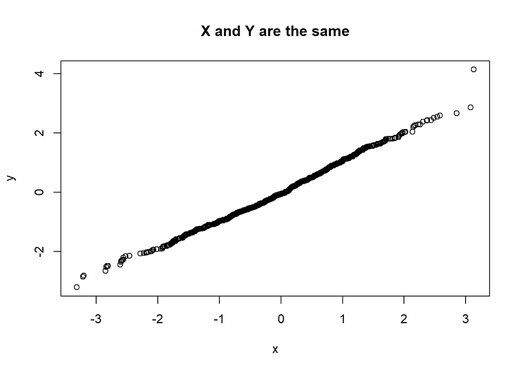

```r
x<-rnorm(1000)
y<-rnorm(1000)
qqplot(x,y,main="X and Y are the same")
```

## low-level

- points(x,y,…) **adds points**
- lines(x,y,…) **adds line segments**
- text(x,y,labels,..) **adds text into the graph**
- abline(a,b,…) **adds the line y=ax+b**
- abline(h=y,…) **adds a horizontal line**
- abline(v=x,…) **adds a vertical line**
- polygon(x,y,…) **adds a polygon**
- segments(x0,y0,x1,y1,…) **draws line segments**
- arrows(x0,y0,x1,y1,…) **draws arrows**
- symbols(x,y,…) **draws circles,squares,…**
- legend(x,y,legend,…) **draws a legend**
- title(main,sub,xlab,ylab,…) **adds a main title, a sub-title, an x-axis label and a y-axis label**
- mtext(text,side,line,…) **draws text in the margins**
- axis(side,at,labels,…) **adds an axis to the plot**
- box(…) **adds a box around the plot region**

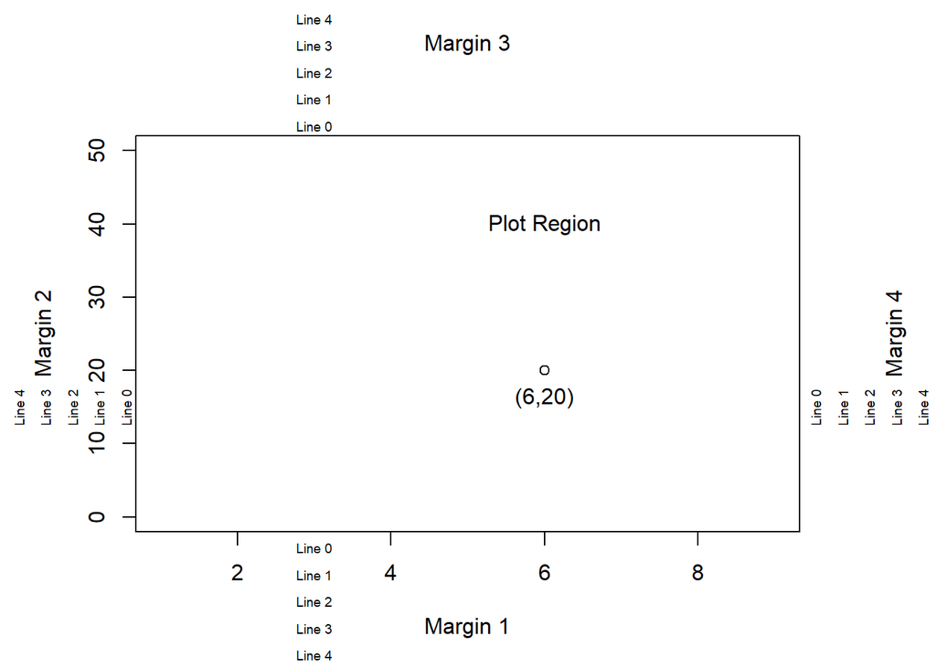

```r
par(mar=c(5,5,5,5)+0.1)
plot(c(1,9),c(0,50),type="n",xlab="",ylab="")
text(6,40,"Plot Region")
points(6,20)
text(6,20,"(6,20)",adj=c(0.5,2))
mtext(paste("Margin",1:4),side=1:4,line=3)
mtext(paste("Line",0:4),side=1,line=0:4,at=3,cex=0.6)
mtext(paste("Line",0:4),side=2,line=0:4,at=15,cex=0.6)
mtext(paste("Line",0:4),side=3,line=0:4,at=3,cex=0.6)
mtext(paste("Line",0:4),side=4,line=0:4,at=15,cex=0.6)
```

### Simulation of other random variables

```r
set.seed(23207) # use this to obtain our output
guesses <- runif(20)
correct.answers <- (guesses < 0.2)
correct.answers
```

```
##  [1] FALSE FALSE FALSE FALSE  TRUE  TRUE  TRUE FALSE  TRUE  TRUE FALSE
## [12] FALSE FALSE FALSE FALSE FALSE FALSE FALSE FALSE  TRUE
```

```r
table(correct.answers)
```

```
## correct.answers
## FALSE  TRUE
##    14     6
```

### Binomial random variables

*dbinom(x, size, prob)*

*P(X = 4) = 0.234, when X is a binomial random variable with m = 6 and p = 0.5.*

```r
dbinom(x = 4, size = 6, prob = 0.5)
```

```
## [1] 0.234375
```

*Pbinom(x,size,prob)*

*P(X <= 4) = 0.890, where X is the number of heads obtained in six tosses of a fair coin as*

```r
pbinom(4, 6, 0.5)
```

```
## [1] 0.890625
```

*The function qbinom() gives the quantiles for the binomial distribution.The 89th percentile of the distribution of X (as defined above) is*

```r
qbinom(0.89,6,0.5)
```

```
## [1] 4
```

### rbinom

*rbinom(n, size, prob)* *Here, size and prob are the binomial parameters, while n is the number of variates generated.*

```r
defectives <- rbinom(24, 15, 0.1)
defectives
```

```
##  [1] 1 2 2 2 1 0 1 2 2 1 2 3 1 0 1 0 1 0 3 2 2 1 0 2
```

### Poisson random variables

*dpois(x, lambda)* *Here, lambda is the Poisson rate parameter, while x is the number of Poisson events. The output from the function is the value of P(X = x).*

```r
dpois(x = 3, lambda = 0.5)
```

```
## [1] 0.01263606
```

*rpois(n, lambda)* *The parameter n is the number of variates produced, and lambda is as above.*

```r
rpois(10, 3.7)
```

```
##  [1] 5 5 2 6 0 1 4 2 2 5
```

### Exponential random numbers

*pexp(q, rate)* *The output from this is the value of P(T ≤ q), where T is an exponential random variable with parameter rate.*

```r
pexp(1, rate = 3)
```

```
## [1] 0.9502129
```

*The R function rexp() can be used to generate n random exponential variates.* *rexp(n, rate)*

```r
servicetimes <- rexp(10, rate = 3)
servicetimes
```

```
##  [1] 0.30811840 0.34188992 0.79840806 0.05053583 0.97660042 0.50273853
##  [7] 0.20992310 0.34392965 0.45242003 0.18683730
```

### Matrix

*matrix(data,nrow,ncol)*

```r
H3 <- matrix(c(1, 1/2, 1/3, 1/2, 1/3, 1/4, 1/3, 1/4, 1/5), nrow=3)
H3
```

```
##           [,1]      [,2]      [,3]
## [1,] 1.0000000 0.5000000 0.3333333
## [2,] 0.5000000 0.3333333 0.2500000
## [3,] 0.3333333 0.2500000 0.2000000
```

*cbind(d1, d2, …, dm)* *rbind(d1, d2, …, dn)*

```r
x=matrix(seq(1,6),nrow=3)
x
```

```
##      [,1] [,2]
## [1,]    1    4
## [2,]    2    5
## [3,]    3    6
```

```r
y=matrix(seq(7,9),nrow=3)
y
```

```
##      [,1]
## [1,]    7
## [2,]    8
## [3,]    9
```

```r
a=matrix(seq(9,7),ncol=3)
a
```

```
##      [,1] [,2] [,3]
## [1,]    9    8    7
```

```r
b=matrix(seq(6,1),ncol=3)
b
```

```
##      [,1] [,2] [,3]
## [1,]    6    4    2
## [2,]    5    3    1
```

```r
cbind(x,y)
```

```
##      [,1] [,2] [,3]
## [1,]    1    4    7
## [2,]    2    5    8
## [3,]    3    6    9
```

*cbind(a,b) error*

*rbind(x,y) error*

```r
rbind(a,b)
```

```
##      [,1] [,2] [,3]
## [1,]    9    8    7
## [2,]    6    4    2
## [3,]    5    3    1
```

### Name of row(column)

*rownames(matrix)=(row_name)* *colnames(matrix)=(column_name)*

```r
A=matrix(c(1,2,3,4,5,6,7,8,9),nrow=3)
rownames(A)=c("first","second","third")
colnames(A)=c("I","II","III")
A
```

```
##        I II III
## first  1  4   7
## second 2  5   8
## third  3  6   9
```

### Inverse matrix

*solve(matrix)*

```r
x=matrix(c(1,4,2,3),nrow=2)
x
```

```
##      [,1] [,2]
## [1,]    1    2
## [2,]    4    3
```

```r
solve(x)
```

```
##      [,1] [,2]
## [1,] -0.6  0.4
## [2,]  0.8 -0.2
```

### Matrix multiplication and inversion

*matrix*matrix isn’t the answer we want.As it will like*

```r
a=matrix(c(1,2,3,4),ncol=2)
b=matrix(c(1,4,9,16),ncol=2)
a
```

```
##      [,1] [,2]
## [1,]    1    3
## [2,]    2    4
```

```r
b
```

```
##      [,1] [,2]
## [1,]    1    9
## [2,]    4   16
```

```r
a*b
```

```
##      [,1] [,2]
## [1,]    1   27
## [2,]    8   64
```

*matrix%*%matrix is what we want*

```r
a%*%b
```

```
##      [,1] [,2]
## [1,]   13   57
## [2,]   18   82
```

### Eigenvalues and eigenvectors

*eigen(matrix) to show eigen vector&value. Use $vectors or $values to show the one you want*

```r
ans=eigen(a)
ans
```

```
## eigen() decomposition
## $values
## [1]  5.3722813 -0.3722813
##
## $vectors
##            [,1]       [,2]
## [1,] -0.5657675 -0.9093767
## [2,] -0.8245648  0.4159736
```

```r
ans=(eigen(a)$vectors)
ans
```

```
##            [,1]       [,2]
## [1,] -0.5657675 -0.9093767
## [2,] -0.8245648  0.4159736
```

# Programming

## the *for()* loop

*for(name){command}*

```r
Fibonacci<-numeric(12)
Fibonacci[1]<-Fibonacci[2]<-1
for (i in 3:12){
  Fibonacci[i]<-Fibonacci[i-2]+Fibonacci[i-1]
}
Fibonacci
```

```
##  [1]   1   1   2   3   5   8  13  21  34  55  89 144
```

## the *if()* statement

*if (conditon){commands when TRUE}else{commands when FALSE}*

```r
x<-3
if (x>2){
  y<-2*x
}else{
  y<-3*x
}
y
```

```
## [1] 6
```

## the *while()* loop

*while(conditon){statements}*

```r
Fib1<-1
Fib2<-1
Fibonacci<-c(Fib1,Fib2)
while (Fib2<300){
  Fibonacci<-c(Fibonacci,Fib2)
  oldFib2<-Fib2
  Fib2<-Fib1+Fib2
  Fib1<-oldFib2
}
Fibonacci
```

```
##  [1]   1   1   1   2   3   5   8  13  21  34  55  89 144 233
```